# RTips

## Intergrating R and C++

For my research I came accross a R challenge whcih involved multiple nested loops with group and subgroup structure. My problem involved updating a vector $x$ where for each group $x^{g}$, if $\|x^{g}\|_2< 2.5$ the group was set to zeros, otherwise each subgroup was updated as: \begin{align} x^{sg} = \|x^{sg}\|_2\times x^{sg} - x^{sg} \end{align}

A simple R solution for this problem is:

```r
gp = rep(1:10^3, each = 20) # groups
sgp = rep(1:(10^3*5), each = 4) # subgroups
n <- length(gp)
x <- rnorm(n)

# Update groups
updateG <- function(x, groups, subgroups){
  newx <- x # preallocate
  ugroups <- unique(groups)
  for(i in ugroups){
    gind <- which(groups == i)
    if(norm(matrix(x[gind],nrow=1), type = "e") < 2.5){
      res <- rep(0, length(gind))
    } else{
      res <- updateSG(x[gind],subgroups[gind])
    }
    newx[gind] <- res
  }
  return(newx)
}

# Update subgroup
updateSG <- function(x, subgroups){
  usubgroups <- unique(subgroups)
  newx <- x
  for(i in usubgroups){
    ind <- which(subgroups == i)
    newx[ind] <- norm(matrix(x[ind], nrow = 1), type = "e")*x[ind] - x[ind]
  }
  return(newx)
}
```

In the application, the update can be repeated hundereds of times so speed is an issue especially in more realistic situations with much larger vectors.

```r
s <- microbenchmark(updateG(x, gp, sgp), times = 10)
```

```
## Unit: milliseconds
##                 expr      min      lq     mean  median       uq      max
##  updateG(x, gp, sgp) 104.2795 104.803 114.3613 105.628 131.7758 133.4892
##  neval
##     10
```

## Using sapply

By using the apply wrappers I thought I’d see some speedup (and possible extension to milticore)

```r
sapplyG <- function(x,groups, subgroups){
  ugroups <- unique(groups)
  newx <- sapply(ugroups, function(i) subGroupFunction(x[which(groups == i)], subgroups[which(groups == i)]))
  return(as.numeric(newx))
}
subGroupFunction <- function(x, subgroups){
  if(norm(matrix(x,nrow=1), type = "e") < 2.5){
    res <- rep(0, length(x))
    }
  else {
    usubgroups <- unique(subgroups)
    res <- sapply(usubgroups, function(j) subsubGroupFunction(x[which(subgroups == j)]))
  }
  return(as.numeric(res))
}
subsubGroupFunction <- function(x){
  return(norm(matrix(x, nrow = 1), type = "e")*x - x)
}
```

Comparing the codes gives some fustrating results:

```r
s <- microbenchmark(updateG(x, gp, sgp), sapplyG(x,gp, sgp), times = 10)
```

```
## Unit: milliseconds
##                 expr      min       lq     mean   median       uq      max
##  updateG(x, gp, sgp) 107.0959 111.3169 119.8822 112.3206 136.3702 144.8872
##  sapplyG(x, gp, sgp) 196.7144 221.6009 220.0997 224.6491 225.9710 233.7845
##  neval
##     10
##     10
```

This is because the sapply method is not preallocating variable size (so each itteration increases the size of the returned vector). Additional time is taken converting the list into a numeric object between sapplys. A good blog on the downfalls of memory allocation in R is http://www.r-bloggers.com/efficient-ragged-arrays-in-r-and-rcpp/.

## Cpp implementation

The Rcpp solution is surprisingly simple and much easier to implement than the sapply version. Some good starting points for including C++ in your R code are: Hadley Wickham’s blog http://adv-r.had.co.nz/Rcpp.html and Dirk Eddelbuettel’s blog http://dirk.eddelbuettel.com/code/rcpp.html. Addtionally the Armadillo library http://arma.sourceforge.net/docs.html provides some great linear algebra functions within c++ that make programing easier.

The folloing code was written in a seperate file from the previous R code. To compile the C++ funcitons the code is sourced and then every function with Rcpp::export is avaliable in the R environment.

```cpp
#include <RcppArmadillo.h>
// [[Rcpp::depends(RcppArmadillo)]]
using namespace Rcpp;
// C++ reads one line at a time so subfunctions are defined first

// Subgroup update function
arma::vec subfun(arma::vec x, arma::vec subgroups){
  arma::vec res(x.size());
  arma::vec usubgroup = unique(subgroups);
  int nsgroups = usubgroup.size();

  for (int ka = 0; ka < nsgroups; ka++){
    arma::umat sgind = arma::find( subgroups == usubgroup(ka)); // find group indicies
    res.elem(sgind) = x.elem(sgind)*arma::norm(x.elem(sgind),2) - x.elem(sgind);
  }
  return res;
}

// Group update
// [[Rcpp::export]]
arma::vec updateC(arma::vec x,arma::vec groups,arma::vec subgroups){
  int n = x.size();
  arma::vec res(n);
  arma::vec ugroups = unique(groups);
  int ngroups = ugroups.size();

  for (int ka = 0; ka < ngroups; ka++){
    arma::umat gind = arma::find( groups == ugroups(ka));
    if(arma::norm(x.elem(gind)) < 2.5){
      res.elem(gind) = arma::zeros(gind.size());
    } else {
      res.elem(gind) = subfun(x.elem(gind), subgroups.elem(gind));
    }
  }
  return res;
}
```

Now to test the functions on a larger example:

```r
gp = rep(1:10^3, each = 25) # groups
sgp = rep(1:(10^3*5), each = 5) # subgroups
n <- length(gp)
x <- rnorm(n)
s <- microbenchmark(updateG(x,gp,sgp), sapplyG(x,gp,sgp), updateC(x,gp,sgp), times = 100)
```

```
## Unit: milliseconds
##                 expr       min        lq      mean    median        uq
##  updateG(x, gp, sgp) 125.10533 132.29971 145.27875 151.78336 156.62084
##  sapplyG(x, gp, sgp) 233.46253 258.87412 262.67111 260.86462 267.19779
##  updateC(x, gp, sgp)  15.97859  16.10506  16.28659  16.15614  16.35366
##        max neval
##  168.21404   100
##  297.27713   100
##   17.35568   100
```

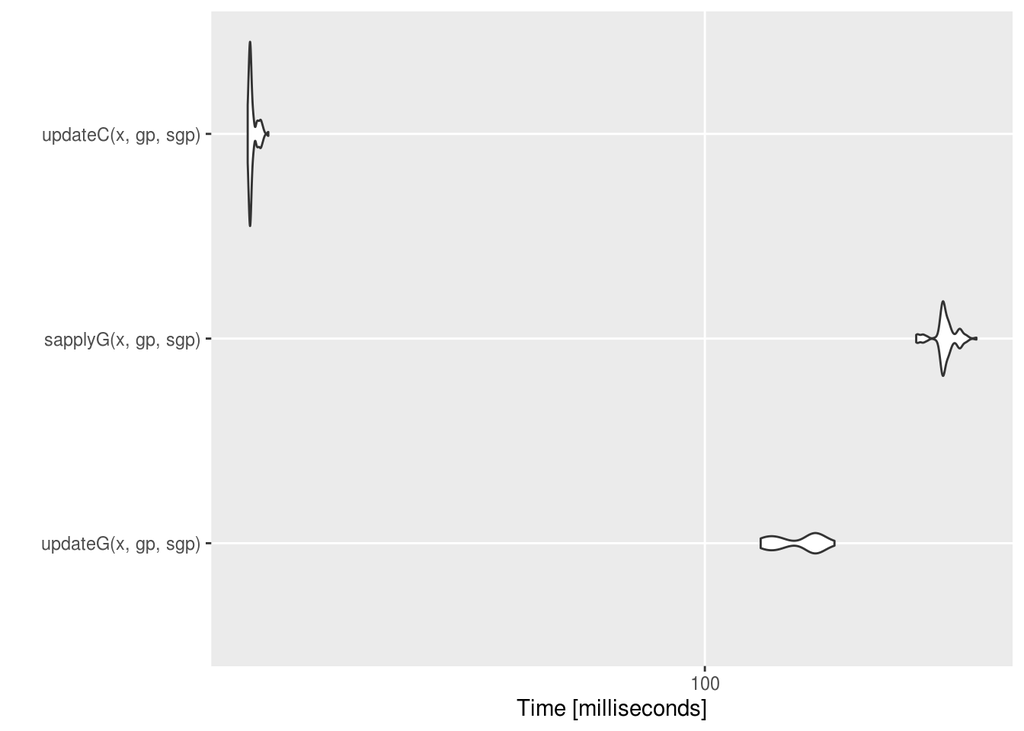